# Lab 4: Multivariate normal and LDA, QDA

Zhanrui Cai

2022-09-14

## Exercise 1 Classification Trees

Bronchopulmonary Dysplasia (BPD) Study (Biostatistics Casebook, pp 104-119)

Training samples consist of all infants at the Stanford Medical Center between 1962 and 1973 who were diagnosed with respiratory distress syndrome (RDS) and received ventilatory assistance for at least 24 hours (except one infant with incomplete records). Most of these babies were born prematurely and had underdeveloped lungs. Some breathing assistance involving elevated levels of oxygen was needed to keep the babies alive. Bronchiopulmonary dysplasia (BPD) is deterioration of lung tissue (scarring) in infants exposed to a high level of oxygen. A panel of physicians reviewed each case to determine if BPD was present.

Infants who did not survive for at least 72 hours were excluded from the analysis because there was not enough time for BPD to develop. One additional infant was excluded due to incomplete records. This reduced the sample from 299 to 248 babies, including 78 with BPD and 170 without BPD.

General background variables: Sex (0=female, 1=male) YOB: year of birth (coded from 62 to 73) APGAR: one minute APGAR score (0 to 10 with 10 as the most healthy) GEST: gestational age (weeks × 10) BWT: birth weight (grams) AGSYM: age at onset of RDS (hours × 10) RDS: severity of initial X-ray for RDS (0 to 5=most severe) Therapy variables: AGVEN: Age at onset of ventilation (hours) VENTL: total hours on the ventilator LOWO2: hours of exposure to (21-39%) levels of oxygen MEDO2: hours of exposure to (40-79%) levels of oxygen HIO2: hours of exposure to (80-100%) levels of oxygen INTUB: hours of endotracheal intubation Response variable: BPD (coded 1=yes, 2=no)

0. Attach the rpart and rpart.plot packages.

```r
set.seed(123)
library(rpart)
library(rpart.plot)
```

1. Construct a classification tree. First convert categorical variables like sex and rds to factors. (There is no need to convert categorical variables into zero-one variables, because it would not change the tree that is produced. Read the data into a data frame and create factors.)

```r
bpdr <- read.csv("bpd.csv", header=T)
bpdr$sex <- as.factor(bpdr$sex)
head(bpdr)
```

|  | id | sex | yob | apgar | gest | bwt | agsym | rds | agven | intub | ventl | lowo2 | medo2 | hio2 | bpd |
| --- | --- | --- | --- | --- | --- | --- | --- | --- | --- | --- | --- | --- | --- | --- | --- |
| 1 | 5 | 1 | 64 | 8 | 400 | 3203 | 10 | 1 | 58 | 41 | 40 | 79 | 26 | 31 | 2 |
| 2 | 1 | 0 | 62 | NA | 370 | 2948 | 0 | 0 | 30 | 88 | 77 | 102 | 89 | 0 | 2 |
| 3 | 2 | 0 | 62 | NA | 360 | 2480 | 3 | 1 | 20 | 209 | 204 | 7 | 233 | 1 | 2 |
| 4 | 6 | 1 | 64 | NA | 320 | 1860 | 0 | 2 | 1 | 653 | 644 | 0 | 625 | 156 | 1 |
| 5 | 7 | 1 | 64 | 9 | NA | 1701 | 5 | 2 | 49 | 40 | 40 | 0 | 12 | 79 | 2 |
| 6 | 8 | 0 | 64 | NA | 310 | 1417 | 5 | 5 | 17 | 103 | 102 | 0 | 3 | 119 | 2 |

2. Create a factor to distinguish the two populations with labels “BPD” and “No BPD”.

```r
bpdr$y[bpdr$bpd==1]<-'BPD'
bpdr$y[bpdr$bpd==2]<-'No BPD'
bpdr$y<-as.factor(bpdr$y)

head(bpdr)
```

|  | id | sex | yob | apgar | gest | bwt | agsym | rds | agven | intub | ventl | lowo2 | medo2 | hio2 | bpd | y |
| --- | --- | --- | --- | --- | --- | --- | --- | --- | --- | --- | --- | --- | --- | --- | --- | --- |
| 1 | 5 | 1 | 64 | 8 | 400 | 3203 | 10 | 1 | 58 | 41 | 40 | 79 | 26 | 31 | 2 | No BPD |
| 2 | 1 | 0 | 62 | NA | 370 | 2948 | 0 | 0 | 30 | 88 | 77 | 102 | 89 | 0 | 2 | No BPD |
| 3 | 2 | 0 | 62 | NA | 360 | 2480 | 3 | 1 | 20 | 209 | 204 | 7 | 233 | 1 | 2 | No BPD |
| 4 | 6 | 1 | 64 | NA | 320 | 1860 | 0 | 2 | 1 | 653 | 644 | 0 | 625 | 156 | 1 | BPD |
| 5 | 7 | 1 | 64 | 9 | NA | 1701 | 5 | 2 | 49 | 40 | 40 | 0 | 12 | 79 | 2 | No BPD |
| 6 | 8 | 0 | 64 | NA | 310 | 1417 | 5 | 5 | 17 | 103 | 102 | 0 | 3 | 119 | 2 | No BPD |

3. Train the decision tree using the function rpart(). Print out the summary of the tree. Which variable did the tree choose to split first? Medo2

```r
bpd.rp <- rpart(y ~ sex+yob+gest+bwt+agsym+agven+intub+ventl+lowo2+medo2+hio2+rds, data=bpdr, cp=0.0001)

summary(bpd.rp)
```

```
## Call:
## rpart(formula = y ~ sex + yob + gest + bwt + agsym + agven +
##     intub + ventl + lowo2 + medo2 + hio2 + rds, data = bpdr,
##     cp = 1e-04)
##   n= 248
##
##            CP nsplit rel error    xerror       xstd
## 1 0.538461538      0 1.0000000 1.0000000 0.09374569
## 2 0.038461538      1 0.4615385 0.5897436 0.07847551
## 3 0.025641026      3 0.3846154 0.5769231 0.07780972
## 4 0.003205128      4 0.3589744 0.5769231 0.07780972
## 5 0.000100000      8 0.3461538 0.5897436 0.07847551
##
## Variable importance
## medo2 intub ventl lowo2  hio2 agven   yob
##    31    19    19    13    10     6     1
##
## Node number 1: 248 observations,    complexity param=0.5384615
##   predicted class=No BPD  expected loss=0.3145161  P(node) =1
##     class counts:    78   170
##    probabilities: 0.315 0.685
##   left son=2 (62 obs) right son=3 (186 obs)
##   Primary splits:
##       medo2 < 183    to the right, improve=45.43011, (0 missing)
##       ventl < 220.5  to the right, improve=43.28307, (1 missing)
##       intub < 271    to the right, improve=39.85744, (0 missing)
##       lowo2 < 437.5  to the right, improve=29.52134, (0 missing)
##       hio2  < 153    to the right, improve=17.09879, (0 missing)
##   Surrogate splits:
##       intub < 286.5  to the right, agree=0.871, adj=0.484, (0 split)
##       ventl < 301.5  to the right, agree=0.863, adj=0.452, (0 split)
##       lowo2 < 429    to the right, agree=0.831, adj=0.323, (0 split)
##       agven < 64.5   to the right, agree=0.786, adj=0.145, (0 split)
##       hio2  < 305    to the right, agree=0.774, adj=0.097, (0 split)
##
## Node number 2: 62 observations,    complexity param=0.02564103
##   predicted class=BPD     expected loss=0.1612903  P(node) =0.25
##     class counts:    52    10
##    probabilities: 0.839 0.161
##   left son=4 (48 obs) right son=5 (14 obs)
```

[output cut: 141 more lines]

```
##
## Node number 61: 14 observations
##   predicted class=No BPD  expected loss=0  P(node) =0.05645161
##     class counts:     0    14
##    probabilities: 0.000 1.000
##
## Node number 120: 7 observations
##   predicted class=BPD     expected loss=0.4285714  P(node) =0.02822581
##     class counts:     4     3
##    probabilities: 0.571 0.429
##
## Node number 121: 20 observations
##   predicted class=No BPD  expected loss=0.15  P(node) =0.08064516
##     class counts:     3    17
##    probabilities: 0.150 0.850
```

4. Using function plot() to display the tree. The arguments of the par( ) function enable all of the text for the node labels to be displayed, otherwise only part of the label can be seen. How many terminal nodes does the tree have? 9 terminal nodes

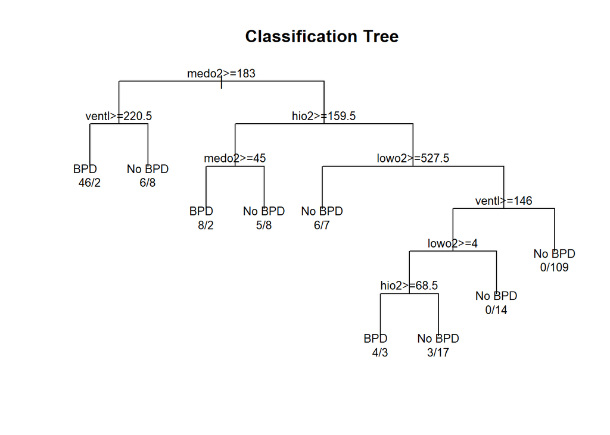

```r
par(mfrow=c(1,1), xpd=NA)
plot(bpd.rp,uniform=T)
text(bpd.rp, use.n=TRUE, cex=0.8)
title("Classification Tree")
```

5. Estimate the predicted probabilities of the two classes using the predict() function. Print the estimated probabilities for the first 10 samples using the head() function.

```r
bpd.prob <- predict(bpd.rp)
head(bpd.prob, 10)
```

[output not shown]